# Fitting Polynomial Regression to Data

Anika Watson

2018-01-16

# Function-Valued Analysis

Many biological traits are not scalar variables but continuous functions (Griswold, Gomulkiewicz & Heckman, 2008; Stinchcombe & Kirkpatrick, 2012; Hadjipantelis et al., 2013). Size, for instance, can be described as a function of age, fur thickness a function of ambient temperature, and so on. Scientific articles in the sphere of function-valued analysis argue that treating such traits as continuous functions provides substantially greater statistical power and other clear advantages over multivariate approaches (Stinchcombe & Kirkpatrick, 2012; Griswold, Gomulkiewicz & Heckman, 2008). The technique works by fitting a function to the data and then running statistics on the coefficients of the approximating function, rather than the data itself.

### Fitting a Function to Data

If you’ve ever hit “add trendline” and “display equation on chart” in excel then you’ve already done this… sort of. Here we will explore how to fit a function to data in R.

First, we need data. I have created a sample dataset comprised of the lengths of the mythical species of fish, R-ctic ch-R. This dataset has both random individual variance, and random measurement error, and details about how the data was generated have been outlined in my *Data Generation* document. Here is a plot of the data:

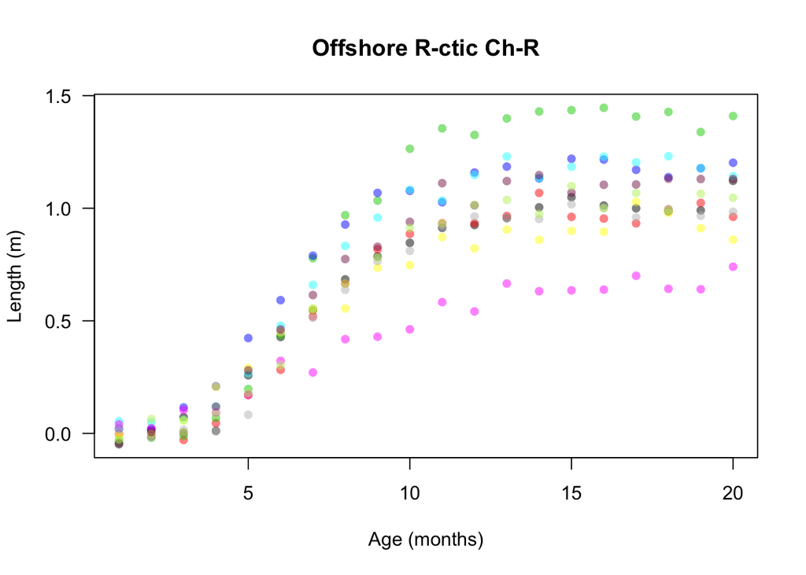

Figure 1: A plot of the ten individuals in the offshore population of R-ctic Ch-R.

Now that we have data we can fit various models to them. Let’s begin with polynmial regression.

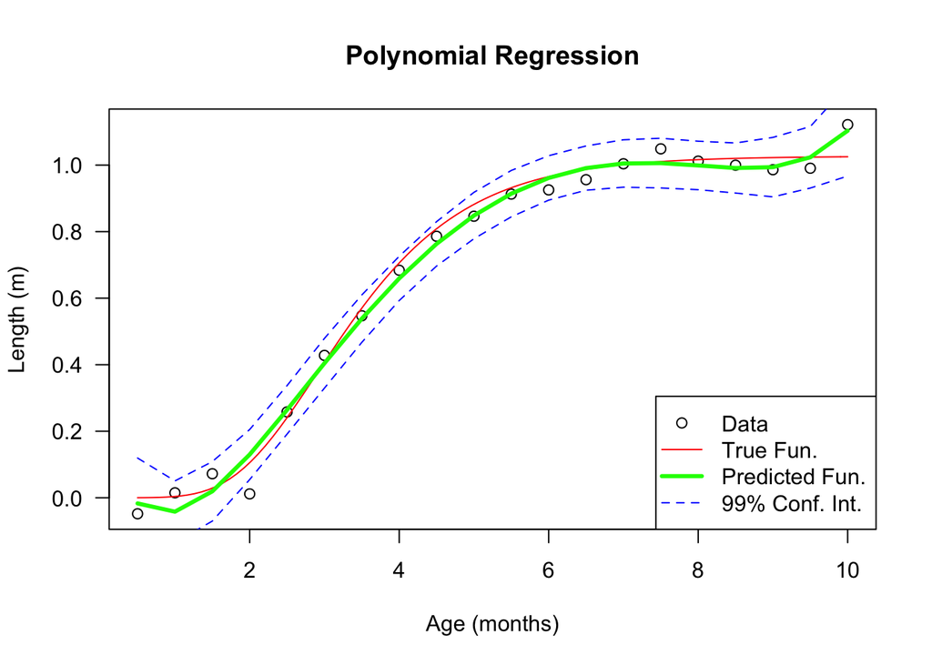

```r
#sliderInput("n", label = "Polynomial Degree", min = 0, max = 10, value = 6, step = 1, round = TRUE)


PolyModelPop1ind1 <- lm(RcticChR1ind1 ~ poly(x = inp, n = 6))

predicted.intervals <- predict(PolyModelPop1ind1, data.frame(x=inp), interval='confidence',
                               level=0.99)

plot(y = RcticChR1ind1, x = seq(from = 0.5, to = 10, by = 0.5), main = "Polynomial Regression", ylab = "Length (m)", xlab = "Age (months)", las = 1)
curve(RcticChR(Mono1akg[1,1], Mono1akg[1,2], Mono1akg[1,3], x), n = 101, add = TRUE, col = "red")
lines(inp,predicted.intervals[,1],col='green', lwd=3)
lines(inp,predicted.intervals[,2],col=4, lwd=1, lty=2)
lines(inp,predicted.intervals[,3],col=4, lwd=1, lty=2)
legend("bottomright",c("Data", "True Fun.", "Predicted Fun.", "99% Conf. Int."),
       col = c("black", "red", "green", 4), pch = c(1, NA, NA, NA), lwd = c(NA, 1, 3, 1), lty = c(1, 1, 1, 2))
```

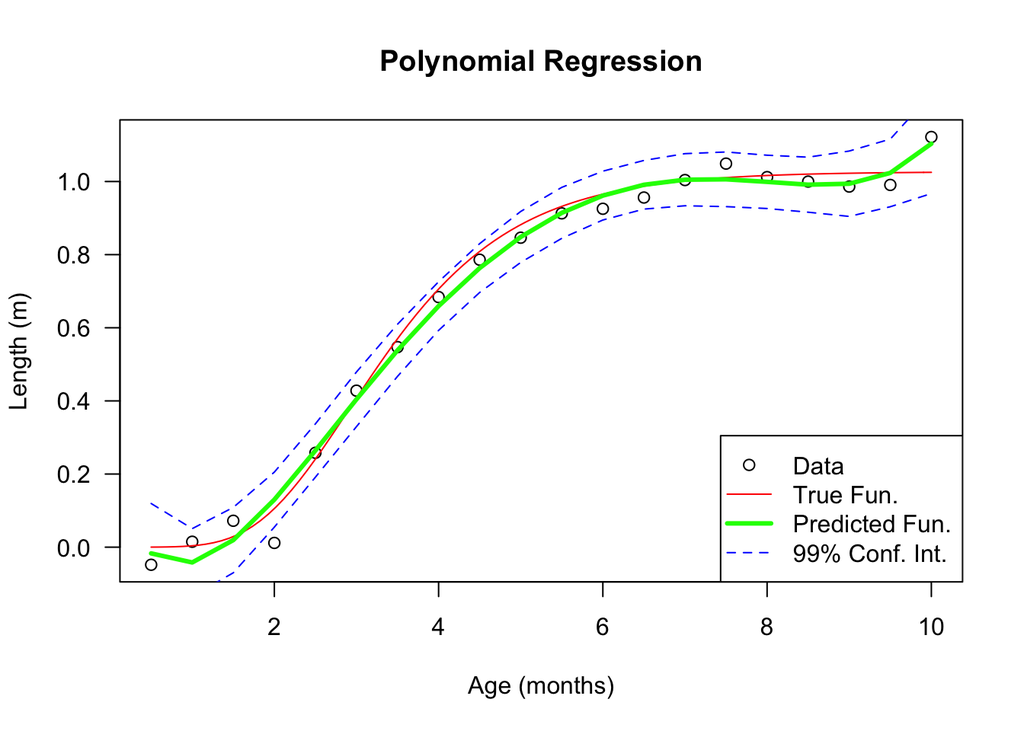

```r
plot(y = RcticChR1ind1, x = seq(from = 0.5, to = 10, by = 0.5), main = "Polynomial Regression", ylab = "Length (m)", xlab = "Age (months)", las = 1)
curve(RcticChR(Mono1akg[1,1], Mono1akg[1,2], Mono1akg[1,3], x), n = 101, add = TRUE, col = "red")
lines(inp,predicted.intervals[,1],col='green', lwd=3)
lines(inp,predicted.intervals[,2],col=4, lwd=1, lty=2)
lines(inp,predicted.intervals[,3],col=4, lwd=1, lty=2)
legend("bottomright",c("Data", "True Fun.", "Predicted Fun.", "99% Conf. Int."),
       col = c("black", "red", "green", 4), pch = c(1, NA, NA, NA), lwd = c(NA, 1, 3, 1), lty = c(1, 1, 1, 2))
```